# Chemical Data Preprocessing

Elise Hickman

# Script Summary

Script within this file was used to:

- Summarize the number of days participants wore wristbands (Table S1)
- Identify participant outliers based on distribution chemical data (Figure S1A)
- Set a chemical detection filter (Figure S1B)
- Quantify the number of chemicals detected in any participant or in at least 20% of participants (Table S2)
- Impute values below the MDL (Figure S2)
- Calculate time-weighted average data
- Assess log2-transformation
- Identify outliers based on PCA analysis of chemical data
- Calculate descriptive statistics (Table S3)

# Set up workspace

```r
# Clear global environment
rm(list=ls())

# Load packages
library(tidyverse) # for data organization and manipulation
library(janitor) # for data cleaning
library(openxlsx) # for reading in and writing out files
library(DT) # for displaying tables
library(table1) # for making tables
library(patchwork) # for graphing
library(ggpubr) # for making qqplots
library(purrr) # for summary stats
library(factoextra) # for PCA outlier detection
select <- dplyr::select

# Set theme
theme_set(theme_bw())

# Set working directory
setwd("/Users/ehickman/Library/CloudStorage/OneDrive-UniversityofNorthCarolinaatChapelHill/Rager_Lab/Projects/2023/BEE_Wristband_Project/4_Analyses/1_CurrentAnalyses/1_DataPreprocess/1_ChemicalData")
```

# Import data

Import data and perform initial data cleaning steps. `mdl` stores the minimum detection levels in ng/g and `wb` stores the wristband chemical data.

```r
# Minimum detection levels in ng/g
mdl <- read.xlsx("1_InputData/Minimum Detection Levels.xlsx", colNames = FALSE) %>%
  t() %>%
  as.data.frame() %>%
  row_to_names(1) %>%
  remove_rownames() %>% # R had assigned unneeded row names
  na.omit() %>% # Some of the rows were completely empty
  dplyr::rename("chemical" = "Name", "mdl" = "MDL (ng/g)", "class_chemical" = "Variable Name", "class" = "Class") %>%
  mutate(mdl = as.numeric(mdl)) %>%
  mutate(across(where(is.numeric), round, 2))

# View MDLs
datatable(mdl)
```

|  | class | chemical | class_chemical | mdl |
| --- | --- | --- | --- | --- |
| 1 | alkylOPE | 2IPPDPP | alkylOPE_2IPPDPP | 0.72 |
| 2 | alkylOPE | 3IPPDPP | alkylOPE_3IPPDPP | 0.09 |
| 3 | alkylOPE | 2tBPDPP | alkylOPE_2tBPDPP | 0.05 |
| 4 | alkylOPE | 4IPPDPP | alkylOPE_4IPPDPP | 0.43 |
| 5 | alkylOPE | B2IPPPP | alkylOPE_B2IPPPP | 0.75 |
| 6 | alkylOPE | 24DIPPDPP | alkylOPE_24DIPPDPP | 2.92 |
| 7 | alkylOPE | 4tBPDPP | alkylOPE_4tBPDPP | 0.81 |
| 8 | alkylOPE | B3IPPPP | alkylOPE_B3IPPPP | 0.19 |
| 9 | alkylOPE | B2tBPPP | alkylOPE_B2tBPPP | 0.05 |
| 10 | alkylOPE | B4IPPPP | alkylOPE_B4IPPPP | 0.08 |

[output cut: 100 more lines]

```r
# Wristband data
wb <- read.csv("1_InputData/UNC_WristBands_DataSummary_111121_ForImport.csv", na.strings = "NA") %>%
  separate(Timepoint, into = c("month_timepoint", NA), sep = "-", remove = FALSE) %>%
  mutate_if(is.character, ~na_if(., '.')) %>%
  filter(month_timepoint == "6") %>% #keeping only 6-month data
  select(-c(Timepoint, month_timepoint))
```

# Preliminary data exploration

What was the distribution of days that participants wore the wristbands?

```r
wb_days <- wb %>%
  dplyr::count(Ndays) %>%
  mutate(prop = prop.table(n)) %>%
  arrange(-Ndays) %>%
  mutate(across(prop, round, 2))

write.xlsx(wb_days, "2_OutputTables/WristbandDays.xlsx")

datatable(wb_days)
```

|  | Ndays | n | prop |
| --- | --- | --- | --- |
| 1 | 7 | 83 | 0.86 |
| 2 | 6 | 6 | 0.06 |
| 3 | 5 | 3 | 0.03 |
| 4 | 3 | 1 | 0.01 |
| 5 | 2 | 2 | 0.02 |
| 6 | 1 | 2 | 0.02 |

How many chemicals are present in each chemical class?

```r
chemical_class_counts <- mdl %>%
  group_by(class) %>%
  summarise(n_chemicals = length(class)) %>%
  bind_rows(summarise(., across(where(is.numeric), sum),
                         across(where(is.character), ~'Total')))

datatable(chemical_class_counts)
```

|  | class | n_chemicals |
| --- | --- | --- |
| 1 | BDE | 10 |
| 2 | BFR | 5 |
| 3 | OPE | 19 |
| 4 | PAH | 23 |
| 5 | PCB | 11 |
| 6 | Pest | 17 |
| 7 | Phthal | 10 |
| 8 | alkylOPE | 15 |
| 9 | Total | 110 |

How many times was each chemical detected across all samples?

```r
chemical_counts <- data.frame(n_detected = colSums(!is.na(wb[, 2:ncol(wb)]))) %>%
  rownames_to_column("class_chemical") %>%
  right_join(mdl %>% dplyr::select(-mdl), by = "class_chemical") %>%
  relocate(n_detected, .after = chemical) %>%
  mutate(n_undetected = nrow(wb) - n_detected,
         perc_detected = n_detected/nrow(wb)*100,
         perc_undetected = n_undetected/nrow(wb)*100) %>%
  mutate(across(c(perc_detected, perc_undetected), round, 2))

datatable(chemical_counts)
```

|  | class_chemical | class | chemical | n_detected | n_undetected | perc_detected | perc_undetected |
| --- | --- | --- | --- | --- | --- | --- | --- |
| 1 | alkylOPE_2IPPDPP | alkylOPE | 2IPPDPP | 97 | 0 | 100 | 0 |
| 2 | alkylOPE_3IPPDPP | alkylOPE | 3IPPDPP | 92 | 5 | 94.85 | 5.15 |
| 3 | alkylOPE_2tBPDPP | alkylOPE | 2tBPDPP | 8 | 89 | 8.25 | 91.75 |
| 4 | alkylOPE_4IPPDPP | alkylOPE | 4IPPDPP | 97 | 0 | 100 | 0 |
| 5 | alkylOPE_B2IPPPP | alkylOPE | B2IPPPP | 78 | 19 | 80.41 | 19.59 |
| 6 | alkylOPE_24DIPPDPP | alkylOPE | 24DIPPDPP | 65 | 32 | 67.01 | 32.99 |
| 7 | alkylOPE_4tBPDPP | alkylOPE | 4tBPDPP | 97 | 0 | 100 | 0 |
| 8 | alkylOPE_B3IPPPP | alkylOPE | B3IPPPP | 6 | 91 | 6.19 | 93.81 |
| 9 | alkylOPE_B2tBPPP | alkylOPE | B2tBPPP | 0 | 97 | 0 | 100 |
| 10 | alkylOPE_B4IPPPP | alkylOPE | B4IPPPP | 87 | 10 | 89.69 | 10.31 |

[output cut: 100 more lines]

How many chemicals were completely undetected?

```r
nrow(chemical_counts %>% filter(perc_detected == 0))
```

```
## [1] 15
```

# Outlier identification (distributions) and chemical filter

## Distribution of chemicals detected by participant

Did any participants have a particularly high number of non-detects?

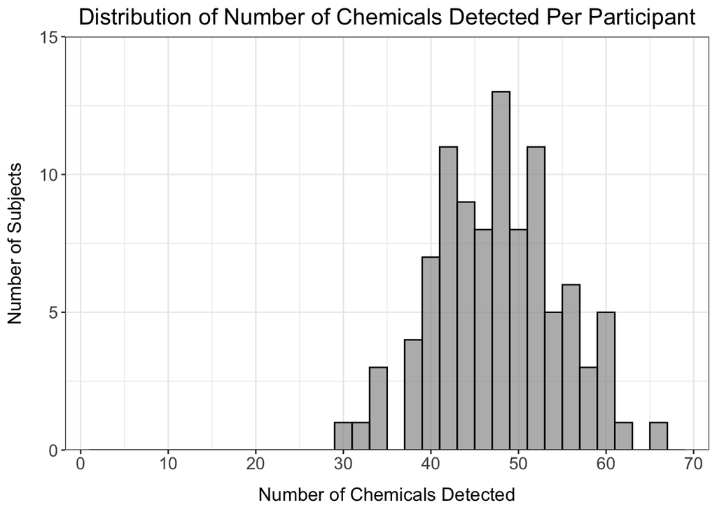

```r
# 6 month
wb_det_bysubj <- wb%>%
  dplyr::select(-Ndays) %>%
  column_to_rownames("S_ID") %>%
  mutate(n_det = rowSums(!is.na(.))) %>%
  mutate(n_NA = rowSums(is.na(.))) %>%
  rownames_to_column("S_ID") %>%
  relocate(c(n_NA, n_det), .after = "S_ID")

det_per_participant_graph <- ggplot(wb_det_bysubj, aes(x = n_det)) +
  geom_histogram(color = "black",
                 fill = "gray60",
                 alpha = 0.7,
                 binwidth = 2) +
  ggtitle("Distribution of Number of Chemicals Detected Per Participant") +
  ylab("Number of Subjects") +
  xlab("Number of Chemicals Detected") +
  scale_x_continuous(breaks = seq(0, 70, by = 10), limits = c(0, 70), expand = c(0.025, 0.025)) +
  scale_y_continuous(breaks = seq(0, 15, by = 5), limits = c(0, 15), expand = c(0, 0)) +
  theme(plot.title = element_text(hjust = 0.5, size = 16),
        axis.title.x = element_text(margin = ggplot2::margin(t = 10), size = 13),
        axis.title.y = element_text(margin = ggplot2::margin(r = 10), size = 13),
        axis.text = element_text(size = 12))

det_per_participant_graph
```

## Distribution of chemical detection by chemical

What was the distribution of chemical detection? (To inform detection filter cutoff)

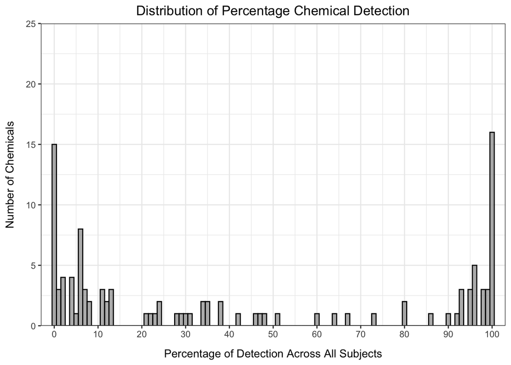

```r
det_per_chemical_graph <- ggplot(chemical_counts, aes(x = perc_detected)) +
    geom_histogram(color = "black",
                   fill = "gray60",
                   alpha = 0.7,
                   binwidth = 1) +
    scale_x_continuous(breaks = seq(0, 100, by = 10), expand = c(0.025, 0.025)) +
    scale_y_continuous(breaks = seq(0, 25, by = 5), limits = c(0, 25), expand = c(0, 0)) +
    ggtitle("Distribution of Percentage Chemical Detection") +
    ylab("Number of Chemicals") +
    xlab("Percentage of Detection Across All Subjects") +
    theme(plot.title = element_text(hjust = 0.5),
        axis.title.x = element_text(margin = ggplot2::margin(t = 10)),
        axis.title.y = element_text(margin = ggplot2::margin(r = 10)))

det_per_chemical_graph
```

Based on these graphs, it appears that there is a natural break at 20%, so we will set our detection filter there.

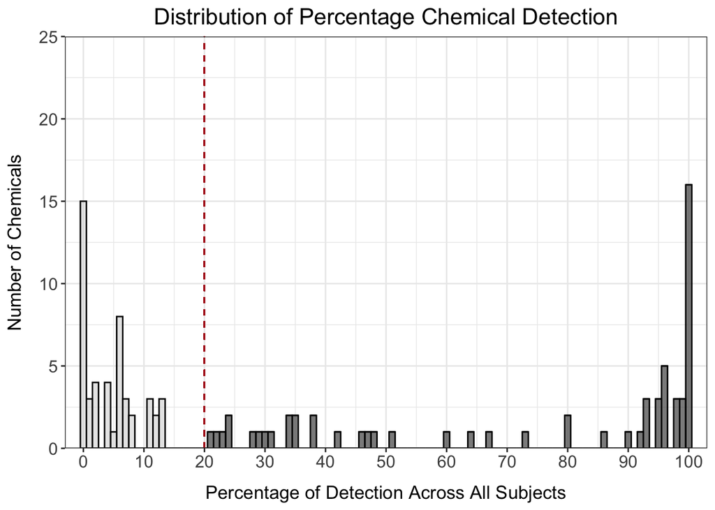

```r
# Add annotation column
chemical_counts <- chemical_counts %>%
  mutate(det_filter = ifelse(perc_detected > 20, "Yes", "No"))

det_per_chemical_graph_annotated <- ggplot(chemical_counts, aes(x = perc_detected, fill = det_filter)) +
  geom_histogram(color = "black",
                 alpha = 0.7,
                 binwidth = 1) +
  scale_fill_manual(values = c("gray87", "gray32"), guide = "none") +
  geom_segment(aes(x = 20, y = 0, xend = 20, yend = 25), color = "firebrick", linetype = 2) +
  scale_x_continuous(breaks = seq(0, 100, by = 10), expand = c(0.025, 0.025)) +
  scale_y_continuous(breaks = seq(0, 25, by = 5), limits = c(0, 25), expand = c(0, 0)) +
  ggtitle("Distribution of Percentage Chemical Detection") +
  ylab("Number of Chemicals") +
  xlab("Percentage of Detection Across All Subjects") +
  theme(plot.title = element_text(hjust = 0.5, size = 16),
        axis.title.x = element_text(margin = ggplot2::margin(t = 10), size = 13),
        axis.title.y = element_text(margin = ggplot2::margin(r = 10), size = 13),
        axis.text = element_text(size = 12))

det_per_chemical_graph_annotated
```

Create final figure panel:

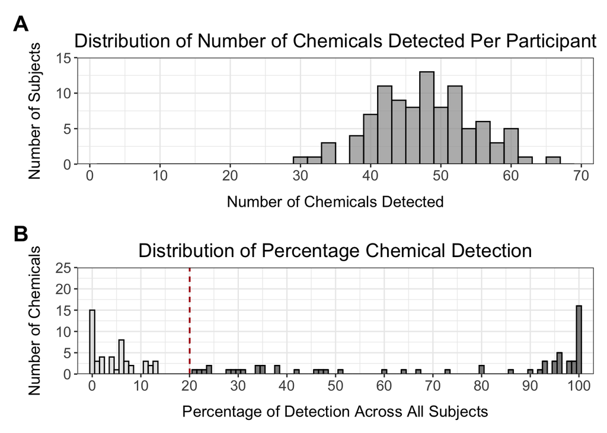

```r
# Final figure panel
figure_panel_chem_det <- det_per_participant_graph / det_per_chemical_graph_annotated +
  plot_annotation(tag_levels = 'A') &
  theme(plot.tag = element_text(face = "bold", size = 18))

pdf(file = "3_OutputFigs/PercentChemDetFilterPanel.pdf",
    height = 7,
    width = 10)

figure_panel_chem_det

invisible(dev.off())

figure_panel_chem_det
```

Apply chemical detection filter.

```r
# Create vector of chemicals to keep
chemicals_20percsubj <- chemical_counts %>%
  filter(perc_detected >= 20)

# Filter data frame
wb_filtered <- wb %>%
  column_to_rownames("S_ID") %>%
  dplyr::select(all_of(chemicals_20percsubj$class_chemical)) %>%
  mutate(across(everything(), as.numeric))
```

What number of chemicals in each class was detected at the threshold of 1) being detected in any sample or 2) being detected in 20% or more of samples?

```r
chemical_count_byclass <- chemical_counts %>%
  filter(class != "Total") %>%
  group_by(class) %>%
  summarise(n_chemicals = n(),
            n_chemicals_det = sum(n_detected > 0),
            n_chemicals_det_20percsubj = sum(perc_detected >= 20)) %>%
  bind_rows(summarise(., across(where(is.numeric), sum),
                         across(where(is.character), ~'Total')))

write.xlsx(chemical_count_byclass, "2_OutputTables/ChemCountDetection_ByClass.xlsx")

datatable(chemical_count_byclass)
```

|  | class | n_chemicals | n_chemicals_det | n_chemicals_det_20percsubj |
| --- | --- | --- | --- | --- |
| 1 | BDE | 10 | 9 | 6 |
| 2 | BFR | 5 | 4 | 2 |
| 3 | OPE | 19 | 17 | 16 |
| 4 | PAH | 23 | 19 | 9 |
| 5 | PCB | 11 | 11 | 2 |
| 6 | Pest | 17 | 13 | 10 |
| 7 | Phthal | 10 | 10 | 8 |
| 8 | alkylOPE | 15 | 12 | 9 |
| 9 | Total | 110 | 95 | 62 |

# Data imputation with GSimp

## Load functions

Application of this code requires use of GSimp package functions, which can be downloaded [here](https://github.com/WandeRum/GSimp). You will also need to install any additional packages that are needed as part of these scripts. The functions from this repository were modified for the current analysis by including MDL values as the last row in the data frame so that the minimum value in the data frame is the MDL, and this is used as the upper limit. Modified GSimp code is included in the repository for this project.

```r
# Load GSimp functions
options(stringsAsFactors = F)

source('/Users/ehickman/Library/CloudStorage/OneDrive-UniversityofNorthCarolinaatChapelHill/Rager_Lab/Projects/2023/BEE_Wristband_Project/4_Analyses/1_CurrentAnalyses/1_DataPreprocess/1_ChemicalData/4_GSimpFunctions/Trunc_KNN/Imput_funcs.r', local = TRUE)

source('/Users/ehickman/Library/CloudStorage/OneDrive-UniversityofNorthCarolinaatChapelHill/Rager_Lab/Projects/2023/BEE_Wristband_Project/4_Analyses/1_CurrentAnalyses/1_DataPreprocess/1_ChemicalData/4_GSimpFunctions/GSimp_evaluation.R', local = TRUE)

source('/Users/ehickman/Library/CloudStorage/OneDrive-UniversityofNorthCarolinaatChapelHill/Rager_Lab/Projects/2023/BEE_Wristband_Project/4_Analyses/1_CurrentAnalyses/1_DataPreprocess/1_ChemicalData/4_GSimpFunctions/GSimp.R', local = TRUE)
```

## Prepare data frame

The input for this function is the detection-filtered data frame with the MDL added as the last row in the data frame.

```r
# Create data frame containing the chemical names and MDLs in the same order as the columns of the filtered data frame
wb_filtered_GSimp_mdls <- wb_filtered %>%
  t() %>%
  as.data.frame() %>%
  rownames_to_column("class_chemical") %>%
  dplyr::select(class_chemical) %>%
  left_join(mdl %>% dplyr::select(c(class_chemical, mdl)), by = "class_chemical") %>%
  dplyr::select(c(class_chemical, mdl))

# Check to make sure mdl values are the same order as the columns in the input data frame. This should return "TRUE."
identical(wb_filtered_GSimp_mdls$class_chemical, names(wb_filtered))
```

```
## [1] TRUE
```

```r
# Add MDLs as a row in the chemical data frame
wb_filtered_forGSimp <- wb_filtered %>%
  t() %>% as.data.frame() %>%
  rownames_to_column("class_chemical") %>%
  left_join(mdl %>% dplyr::select(c(class_chemical, mdl)), by = "class_chemical") %>%
  column_to_rownames("class_chemical") %>%
  t() %>% as.data.frame() %>%
  mutate(across(everything(), as.numeric))
```

## Run imputation

```r
# Apply function
set.seed(407)
wb_filt_imp <- pre_processing_GS_wrapper(wb_filtered_forGSimp)
```

```
## Iteration 1 start...end!
## Iteration 2 start...end!
## Iteration 3 start...end!
## Iteration 4 start...end!
## Iteration 5 start...end!
## Iteration 6 start...end!
## Iteration 7 start...end!
## Iteration 8 start...end!
## Iteration 9 start...end!
## Iteration 10 start...end!
```

## Assess imputation

How many values did GSimp impute above the MDL?

```r
# Make data frame with original data that indicates whether a value was missing or not
wb_imp_annotation <- wb_filtered %>%
  rownames_to_column("S_ID") %>%
  pivot_longer(!S_ID, names_to = "class_chemical", values_to = "Value") %>%
  unite("unique_id",  c(S_ID, class_chemical), remove = FALSE) %>%
  mutate(was_na = ifelse(is.na(Value), "Yes", "No")) %>%
  dplyr::select(unique_id, was_na)

# Add annotation column and mdl to imputed data frame
wb_filt_imp_summary <- wb_filt_imp %>%
  rownames_to_column("S_ID") %>%
  pivot_longer(!S_ID, names_to = "class_chemical", values_to = "Value") %>%
  unite("unique_id",  c(S_ID, class_chemical), remove = FALSE) %>%
  left_join(wb_imp_annotation, by = "unique_id") %>%
  left_join(mdl, by = "class_chemical")

# Count how many observations were NA before imputation
wb_total_na <- nrow(wb_filt_imp_summary %>% filter(was_na == "Yes"))

# Count how many imputed values are above MDL for each chemical
wb_filt_imp_summary_table <- wb_filt_imp_summary %>%
  filter(was_na == "Yes") %>%
  mutate(high_mdl = ifelse(Value > mdl, "Yes", "No")) %>%
  group_by(class_chemical) %>%
  summarize(count_above_mdl = sum(high_mdl == "Yes"))

datatable(wb_filt_imp_summary_table)
```

|  | class_chemical | count_above_mdl |
| --- | --- | --- |
| 1 | BDE_100 | 0 |
| 2 | BDE_153 | 1 |
| 3 | BDE_154 | 1 |
| 4 | BDE_209 | 0 |
| 5 | BDE_47 | 0 |
| 6 | BDE_99 | 0 |
| 7 | BFR_BEHTBP | 0 |
| 8 | BFR_EHTBB | 0 |
| 9 | OPE_TCEP | 0 |
| 10 | OPE_TCPP3 | 0 |

[output cut: 36 more lines]

```r
# Count total number of imputed values
sum(wb_filt_imp_summary_table$count_above_mdl)
```

```
## [1] 16
```

```r
# Calculate percentage of total NAs that were imputed above the MDL
sum(wb_filt_imp_summary_table$count_above_mdl)/wb_total_na*100
```

```
## [1] 1.033592
```

Graph imputed values (red) with MDL shown as dotted line.

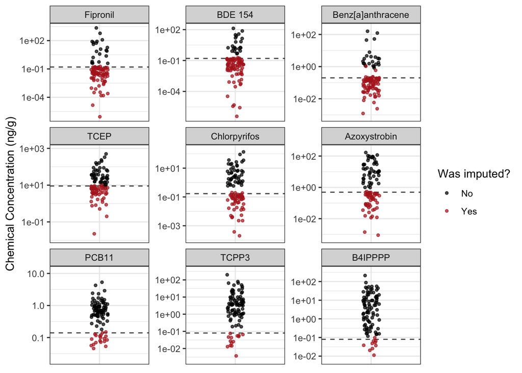

```r
# Determine which chemicals to graph - will graph 3 least abundant, 3 middle abundant, 3 high abundant (but not 100% detection). This subset was selected by manual inspection of chemical count data.
chemicals_for_gsimp_graph_df <- data.frame(
  "class_chemical" = c("Pest_Fipronil", "BDE_154", "PAH_Benzaanth", "OPE_TCEP", "Pest_Chlorpyrifos", "Pest_Azoxystrobin", "PCB_11", "OPE_TCPP3", "alkylOPE_B4IPPPP"),
  "abundance_group" = c("Low", "Low", "Low", "Medium", "Medium", "Medium", "High", "High", "High"))

# Make a vector with names of chemicals to graph
chemicals_for_gsimp_graph <- chemicals_for_gsimp_graph_df$class_chemical

# Add placeholder column and filter data frame to include only sample of chemicals to highlight and add annotation for low, high, or medium abundance
wb_filt_imp_summary_forgraph <- wb_filt_imp_summary %>%
  filter(class_chemical %in% chemicals_for_gsimp_graph) %>%
  left_join(chemicals_for_gsimp_graph_df, by = "class_chemical") %>%
  mutate(placeholder = "1")

# Level Facet Plot By Low/High/Medium
wb_filt_imp_summary_forgraph$chemical <- factor(wb_filt_imp_summary_forgraph$chemical, levels = c("Fipronil", "BDE 154", "Benz[a]anthracene", "TCEP", "Chlorpyrifos", "Azoxystrobin", "PCB11", "TCPP3", "B4IPPPP"))

# Make figure panel showing imputed versus non-imputed values
set.seed(854)

imputation_panel <- ggplot(data = wb_filt_imp_summary_forgraph, aes(x = placeholder, y = Value)) +
  geom_hline(aes(yintercept = mdl), linetype = 2, color = "grey32") +
  geom_point(aes(color = was_na),
             size = 1,
             alpha = 0.7,
             position=position_jitter(width=0.1, height=0.1)) +
  scale_color_manual(values = c("black", "firebrick"), name = "Was imputed?", labels = c("No", "Yes")) +
  labs(y = "Chemical Concentration (ng/g)") +
  scale_y_log10(expand = c(0, 0.5)) +
  theme(axis.ticks.x = element_blank(),
        axis.title.x = element_blank(),
        axis.text.x = element_blank()) +
  facet_wrap(~chemical, scales = "free_y", nrow = 3)

pdf(file = "3_OutputFigs/GSimp_Imp_Panel.pdf",
    width = 7,
    height = 5)

imputation_panel

invisible(dev.off())

imputation_panel
```

# Time-weighted average and log2-transformation

```r
# Write pseudolog function
pseudolog <- function(x) {log2(x+1)}

# Time weighted average data
wb_filt_imp_tw <- wb_filt_imp %>%
  rownames_to_column("S_ID") %>%
  mutate(S_ID = as.integer(S_ID)) %>%
  right_join(wb %>% dplyr::select(S_ID, Ndays), by = "S_ID") %>%
  mutate(S_ID = as.character(S_ID)) %>%
  relocate(Ndays, .after = S_ID) %>%
  mutate(across(where(is.numeric), .fns = function(x) x/Ndays)) %>%
  dplyr::select(-Ndays) %>%
  column_to_rownames("S_ID")

# Time weighted average + log2 transformation
wb_filt_imp_tw_log2 <- wb_filt_imp %>%
  rownames_to_column("S_ID") %>%
  mutate(S_ID = as.integer(S_ID)) %>%
  right_join(wb %>% dplyr::select(S_ID, Ndays), by = "S_ID") %>%
  mutate(S_ID = as.character(S_ID)) %>%
  relocate(Ndays, .after = S_ID) %>%
  mutate(across(where(is.numeric), .fns = function(x) x/Ndays)) %>%
  dplyr::select(-Ndays) %>%
  column_to_rownames("S_ID") %>%
  mutate(across(everything(), .fns = pseudolog))
```

# Assessment of normality of chemical data pre- and post- log2 transformation

## Write function to test normality

This function takes the input of a numeric data frame with variables in columns and samples/subjects in rows and assesses normality through four different approaches:

1. Quantitative - Individual endpoint values of Shapiro Wilk Test with BH p-adjust < 0.05
2. Quantitative - Summary level Shapiro Wilk results quantifying percentage of endpoints that were normal versus non-normal by BH p-adjust < 0.05
3. Qualitative - Histograms
4. Qualitative - QQ plots.

Each of these results are store in a list, which is the final output of the function. Each item can be called with their respective numbers.

```r
normality_assessment <- function(data) {

  ## [1] SHAPIRO WILK TEST WITH ALL ENDPOINTS

  # Test normality of each chemical
  shapiro_wilk <- apply(data, 2, shapiro.test)

  # Create data frame to summarize results
  shapiro_wilk <- do.call(rbind.data.frame, shapiro_wilk)
  shapiro_wilk <- format(shapiro_wilk, scientific = FALSE)

  # Add column to adjust for multiple hypothesis testing
  shapiro_wilk$p.value.adj <- p.adjust(shapiro_wilk$p.value, "BH")

  # Add column for normality conclusion
  shapiro_wilk <- shapiro_wilk %>% mutate(normal = ifelse(p.value.adj < 0.05, F, T))

  ## [2] SHAPIRO WILK TEST SUMMARY

  # Make new data frame with summary values
  shapiro_wilk_summ <- data.frame("count_normal" = nrow(shapiro_wilk %>% filter(p.value.adj >= 0.05)),
                                 "count_nonnormal" = nrow(shapiro_wilk %>% filter(p.value.adj < 0.05))) %>%
  mutate("perc_normal" = count_normal/(count_normal + count_nonnormal)*100)

  ## [3] PANEL OF HISTOGRAMS

  histograms <- data %>%
  pivot_longer(all_of(colnames(data)), names_to = "endpoint", values_to = "value") %>%
  ggplot(aes(value)) +
  geom_histogram(fill = "gray32", color = "black") +
  facet_wrap(~ endpoint, scales = "free")

  ## [4] PANEL OF QQ PLOTS

  qqplots <- ggqqplot(data %>%
  pivot_longer(all_of(colnames(data)), names_to = "endpoint", values_to = "value"),
  "value", facet.by = "endpoint", ggtheme = theme_bw(), scales = "free")

  ## STORE RESULTS
  results <- list(shapiro_wilk, shapiro_wilk_summ, histograms, qqplots)

}
```

## Apply function to data and extract results

Raw data:

```r
# Run function
wb_filt_imp_tw_normality <- normality_assessment(wb_filt_imp_tw)

# View average p-adj
mean(wb_filt_imp_tw_normality[[1]]$p.value.adj)
```

```
## [1] 1.272445e-11
```

```r
# View percent normal
wb_filt_imp_tw_normality[[2]]
```

```
##   count_normal count_nonnormal perc_normal
## 1            0              62           0
```

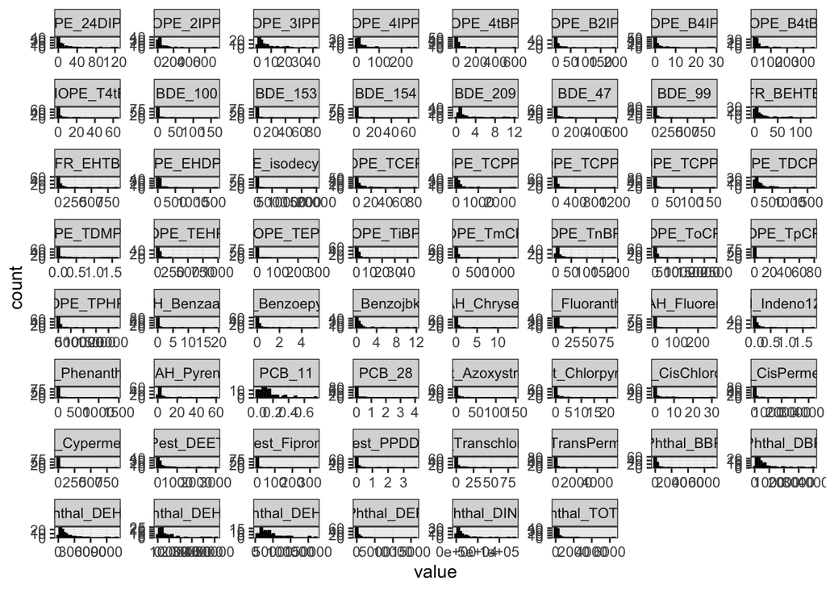

```r
# View histograms
wb_filt_imp_tw_normality[[3]]
```

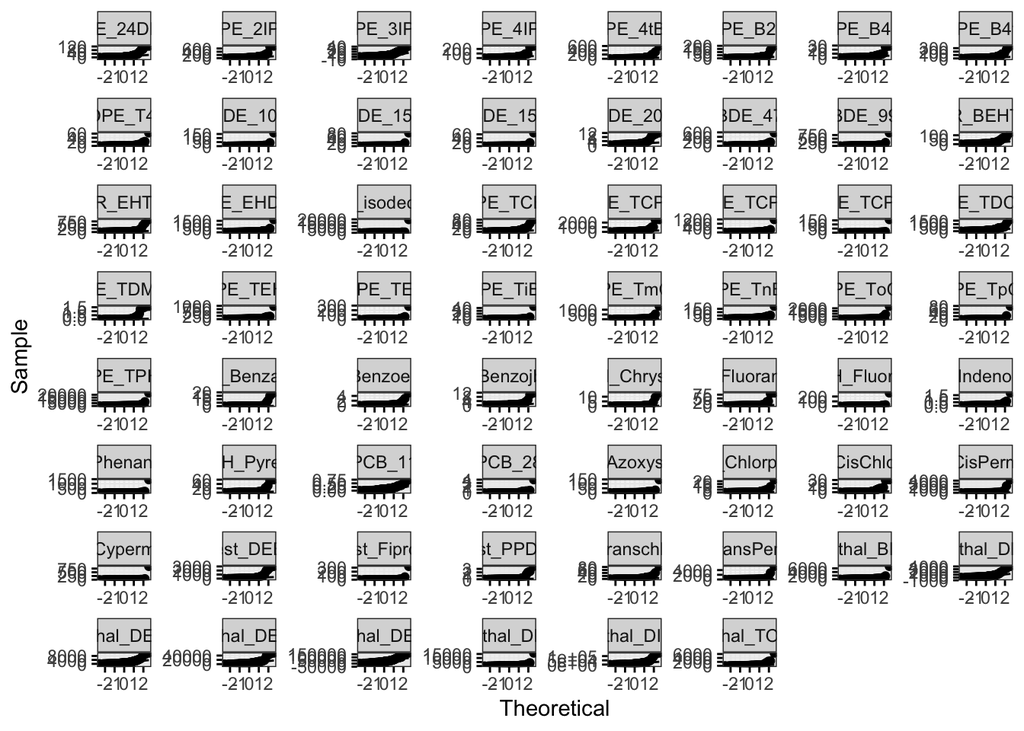

```r
# View qqplots
wb_filt_imp_tw_normality[[4]]
```

Log2 data:

```r
# Run function
wb_filt_imp_tw_log2_normality <- normality_assessment(wb_filt_imp_tw_log2)

# View average p-adj
mean(wb_filt_imp_tw_log2_normality[[1]]$p.value.adj)
```

```
## [1] 0.06425829
```

```r
# View percent normal
wb_filt_imp_tw_log2_normality[[2]]
```

```
##   count_normal count_nonnormal perc_normal
## 1           10              52    16.12903
```

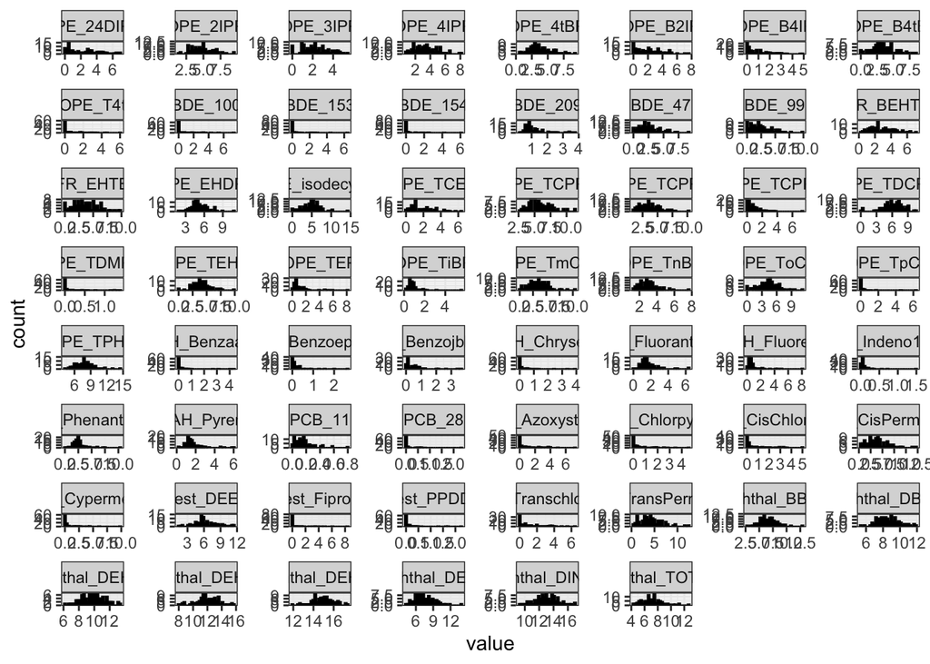

```r
# View histograms
wb_filt_imp_tw_log2_normality[[3]]
```

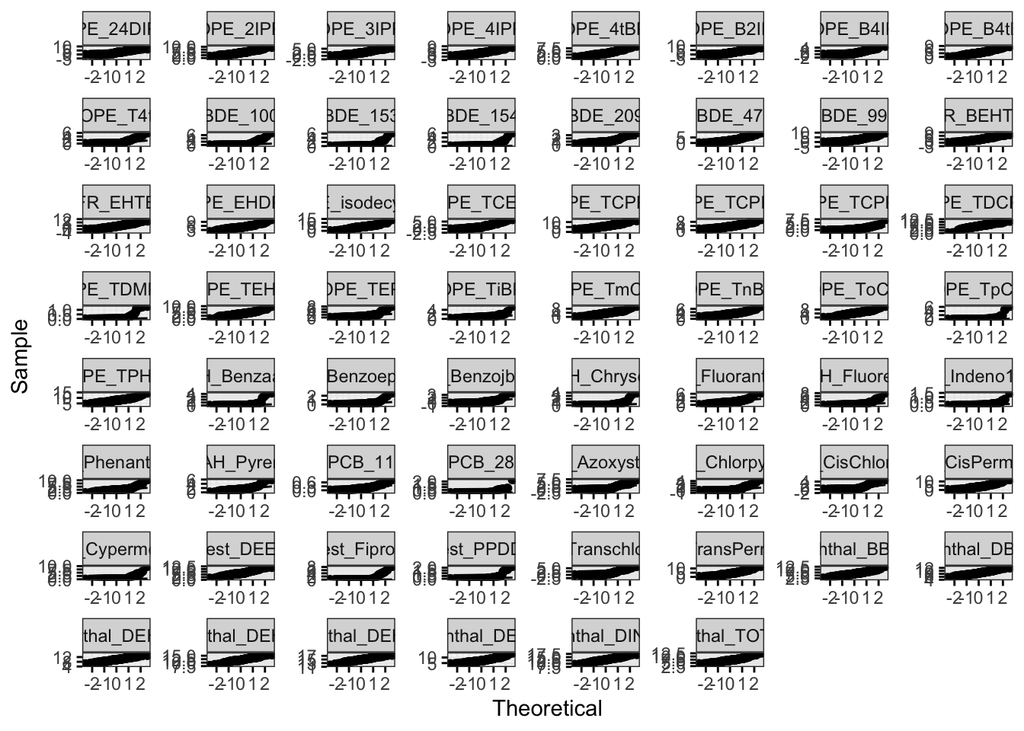

```r
# View qqplots
wb_filt_imp_tw_log2_normality[[4]]
```

Log2 transforming data moves data closer to a normal distribution, so we will move forward with data in that format for subsequent analyses.

```r
# Write out time-weighted average data for downstream analyses
write.xlsx(wb_filt_imp_tw %>% rownames_to_column("S_ID"), file = "5_OutputData/ChemicalData_Filtered_Imp_TW.xlsx")
```

# Outlier identification (PCA)

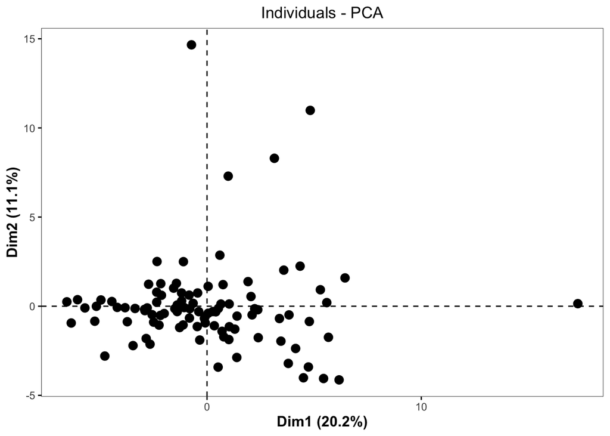

```r
# Prepare data frame
wb_log2_sc <- wb_filt_imp_tw_log2 %>%
  scale() %>% # Scale values
  data.frame() # Change back to data frame

# Run PCA
pca <- prcomp(wb_log2_sc)

# Visualize PCA
pca_chemplot <- fviz_pca_ind(pca,
             label = "none",
             pointsize = 3) +
theme(axis.title = element_text(face = "bold", size = rel(1.1)),
      panel.border = element_rect(fill = NA, color = "black", linewidth = 0.3),
      panel.grid.minor = element_blank(),
      panel.grid.major = element_blank(),
      plot.title = element_text(hjust = 0.5),
      legend.position = "none")

pca_chemplot
```

By visual inspection, it looks like there may be some outliers, so we can use a formula to detect outliers. One standard way to detect outliers is the criterion of being “more than 6 standard deviations away from the mean.” [Source](https://privefl.github.io/blog/detecting-outlier-samples-in-pca/).

```r
# Create a scoring funciton to detect PCA sample outliers. The input is PCA results data frame and the number of standard deviations for the cutoff. The output is outlier names.
outlier_detection = function(pca_df, sd){

    # getting scores
    scores = pca_df$x

    # identifying samples that are > 6 standard deviations away from the mean
    outlier_indices = apply(scores, 2, function(x) which( abs(x - mean(x)) > (sd * sd(x)) )) %>%
        Reduce(union, .)

    # getting sample names
    outliers = rownames(scores)[outlier_indices]

    return(outliers)
}

# Call function with different standard deviation cutoffs
outliers_6 <- outlier_detection(pca, 6)
outliers_5 <- outlier_detection(pca, 5)
outliers_4 <- outlier_detection(pca, 4)
outliers_3 <- outlier_detection(pca, 3)

# Summary data frame
outlier_summary <- data.frame(sd_cutoff = c(6, 5, 4, 3), n_outliers = c(length(outliers_6), length(outliers_5), length(outliers_4), length(outliers_3)))

outlier_summary
```

```
##   sd_cutoff n_outliers
## 1         6          0
## 2         5          1
## 3         4          5
## 4         3         28
```

We don’t see any outliers that are > 6 SD form the mean, so we will proceed with the dataset without filtering any participants out.

# Descriptive statistics

```r
# Define summary functions
summary_functs <- lst(min, median, mean, max, sd)

# Raw data
wb <- wb %>% mutate(across(2:ncol(wb), as.numeric))

raw_summarystats <- map_dfr(summary_functs, ~ summarize(wb, across(2:ncol(wb), .x, na.rm = TRUE)), .id = "statistic") %>%
  t() %>%
  as.data.frame() %>%
  row_to_names(1) %>%
  na.omit() %>%
  rownames_to_column("class_chemical") %>%
  left_join(mdl %>% dplyr::select(-mdl), by = "class_chemical") %>%
  mutate(across(min:sd, as.numeric)) %>%
  mutate(across(where(is.numeric), round, 2)) %>%
  arrange(-mean)

# Filtered + imputed data
imp_summarystats <- map_dfr(summary_functs,
                                 ~ summarize(wb_filt_imp, across(1:ncol(wb_filt_imp),
                                                                       .x, na.rm = TRUE)), .id = "statistic") %>%
  t() %>%
  as.data.frame() %>%
  row_to_names(1) %>%
  rownames_to_column("class_chemical") %>%
  left_join(mdl %>% dplyr::select(-mdl), by = "class_chemical") %>%
  mutate(across(min:sd, as.numeric)) %>%
  mutate(across(where(is.numeric), round, 2)) %>%
  arrange(-mean) %>%
  relocate(c(class, chemical), .after = class_chemical) %>%
  rename_with(~paste0(., "_imputed"), min:sd)

# Filtered + imputed + TWA data
imp_tw_summarystats <- map_dfr(summary_functs,
                                 ~ summarize(wb_filt_imp_tw, across(1:ncol(wb_filt_imp_tw),
                                                                       .x, na.rm = TRUE)), .id = "statistic") %>%
  t() %>%
  as.data.frame() %>%
  row_to_names(1) %>%
  rownames_to_column("class_chemical") %>%
  left_join(mdl %>% dplyr::select(-mdl), by = "class_chemical") %>%
  mutate(across(min:sd, as.numeric)) %>%
  mutate(across(where(is.numeric), round, 2)) %>%
  arrange(-mean) %>%
  relocate(c(class, chemical), .after = class_chemical) %>%
  rename_with(~paste0(., "_imputed_tw"), min:sd)

# Import chemical name, CAS, and DTXSIDs.
cas_dtxs <- read.xlsx("1_InputData/CAS_DTXSID.xlsx") %>%
  clean_names() %>%
  mutate(chemical = recode(chemical, "pyraclostrobin" = "Pyraclostrobin")) # recode these two chemical names so they match the chemical data

# Combine descriptive statistics and count/detection data, first with just the raw summary stats, then with the other iterations of the data
wb_summarystats <- chemical_counts %>%
  full_join(raw_summarystats %>% dplyr::select(-c(chemical, class)), by = "class_chemical") %>%
  relocate(c(class, chemical), .after = class_chemical) %>%
  rename_with(~paste0(., "_raw"), min:sd) %>%
  relocate(n_detected:perc_undetected, .after = chemical) %>%
  right_join(mdl %>% dplyr::select(c(class_chemical, mdl)), by = "class_chemical") %>%
  relocate(mdl, .after = chemical) %>%
  full_join(imp_summarystats %>% dplyr::select(-c(class, chemical)), by = "class_chemical") %>%
  full_join(imp_tw_summarystats %>% dplyr::select(-c(class, chemical)), by = "class_chemical") %>%
  full_join(cas_dtxs %>% dplyr::select(-c(cas_cas_number)), by = "chemical") %>%
  relocate("compound_name", .before = "chemical") %>%
  relocate(c("cas_number", "dtxsid"), .after = "chemical") %>%
  rename("chemical_name" = "compound_name", "chemical_abbreviation" = "chemical") %>%
  dplyr::select(-class_chemical) %>%
  group_by(class) %>%
  arrange(-mean_raw, .by_group = TRUE) %>%
  mutate(across(everything(), as.character)) %>%
  replace(is.na(.), "-") %>%
  dplyr::select(-c(n_undetected, perc_undetected))

# Write out table for supplement
write.xlsx(wb_summarystats, file = "2_OutputTables/SummaryStats_ByChemical.xlsx")
```